# Client type behaviours in Ford GoBike System

## by Ahmad ALMosallam

## Investigation Overview

I will compare the two types of Client in Ford GoBike System Dateset, customers and subscribers, in the following features:

- Distance travel
- Rental Access Method (App or Clipper)
- Trip duration
- Day

## Dataset Overview

Ford GoBike System Dateset is a dateset that contains trip data from lyft's bike service for public use. Variables including, trip duration, start time and end time with date, start station and end station names, start and end coordinates, customer type, Rental Access Method.

## Number of Subscribers and Customers

In this dataset the number of subscribers is more than the customers.

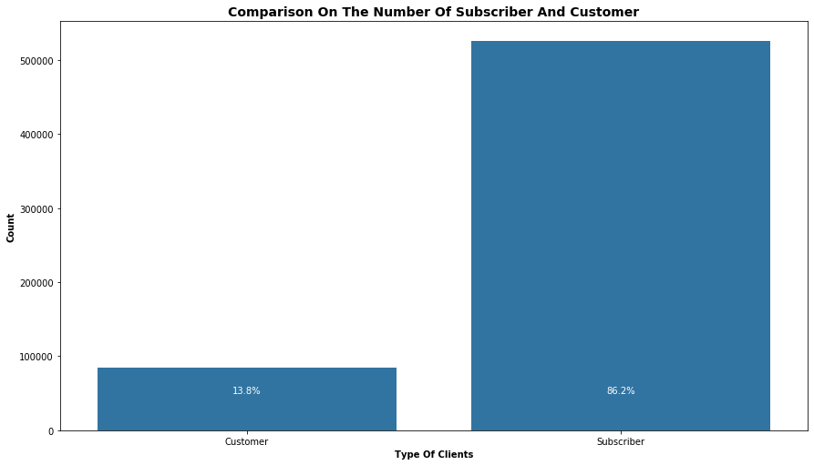

```python
# Plot of the type of users
plt.figure(figsize=[14.70 , 8.27]);
type_user = df.user_type.value_counts()
sb.countplot(data = df , x = 'user_type' , color = sb.color_palette()[0]);
plt.title('comparison on the number of Subscriber and customer'.title() , fontsize=14 , weight = 'bold');
plt.ylabel('Count'.title() , fontsize=10 , weight = 'bold')
plt.xlabel('Type of clients'.title() , fontsize=10 , weight = 'bold');
locs, labels = plt.xticks() # get the current tick locations and labels
# loop through each pair of locations and labels
for loc, label in zip(locs, labels):

    # get the text property for the label to get the correct count
    count = type_user[label.get_text()]
    pct_string = '{:0.1f}%'.format(100*count/df.shape[0])

    # print the annotation just below the top of the bar
    plt.text(loc, 50000, pct_string, ha = 'center', color = 'w');
```

## Clients VS Duration

Subscribers are more likey to spend less time on the trips, while customers are more likey to spend more time on the trips.

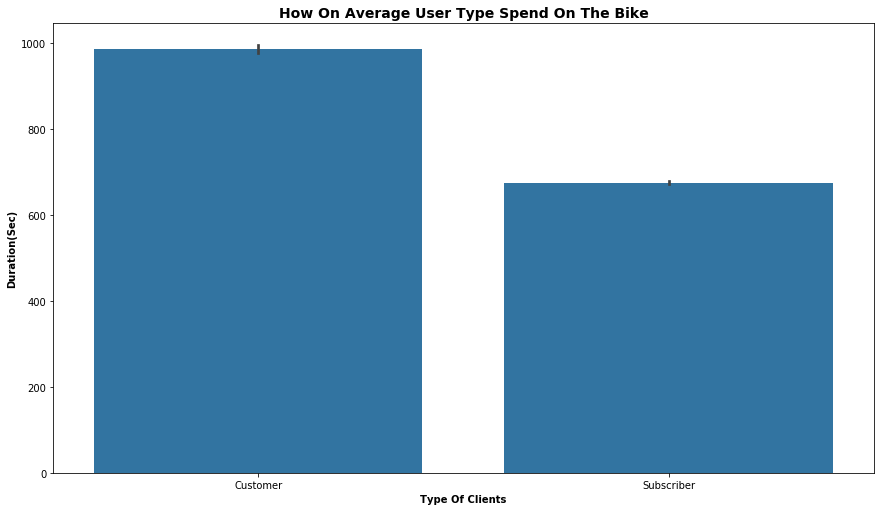

```python
plt.figure(figsize=[14.70 , 8.27]);
sb.barplot(data = df.query("distance <= 2133+ 1.5*1247"),x = 'user_type',y='duration_sec',
               color = sb.color_palette()[0]);
plt.title('How on average user type spend on the bike'.title() , fontsize=14 , weight = 'bold');
plt.xlabel('Type of clients'.title() , fontsize=10 , weight = 'bold');
plt.ylabel('Duration(sec)'.title() , fontsize=10 , weight = 'bold');
```

## User type VS Rental Access Method

Most of the customers use app method and a slight of them use clipper method, also the same for subscribers, most of them use app method.

It tends to the clients to use the app method than the clipper method

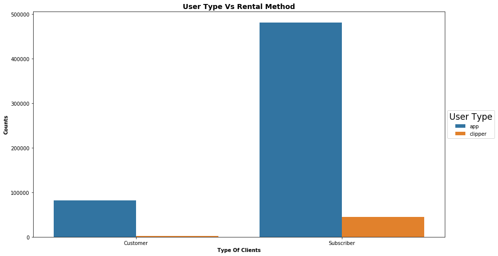

```python
plt.figure(figsize=[14.70 , 8.27]);
sb.countplot(data = df , x = 'user_type' , hue='rental_access_method');
plt.title('User type VS Rental Method'.title() , fontsize=14 , weight = 'bold');
plt.xlabel('Type of clients'.title() , fontsize=10 , weight = 'bold');
plt.ylabel('Counts'.title() , fontsize=10 , weight = 'bold');
plt.legend(loc ='center left' , bbox_to_anchor=(1,0.5) , title='User Type' , title_fontsize = 17);
```

# Client VS Distance VS Day

Customers have longer trips than subscribers on all the days, which means they have longer trips than the subscribers in overall.

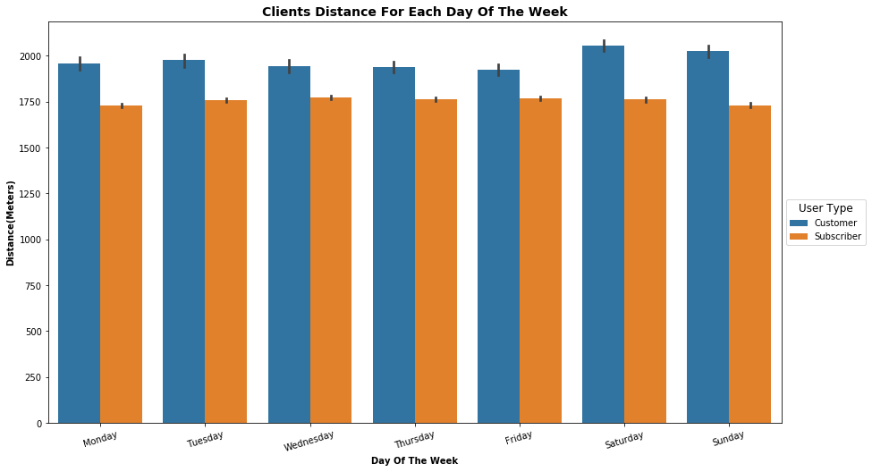

```python
# List of days in order
day_order = ['Monday', 'Tuesday','Wednesday','Thursday', 'Friday', 'Saturday', 'Sunday']
# create ordered categorical variable
df['day'] = pd.Categorical(df['day'],
                           categories= day_order,
                           ordered = True)
plt.figure(figsize=[14.70 , 8.27])
sb.barplot(data=df , x = 'day' , y = 'distance' , hue = 'user_type');
plt.xticks(rotation = 17);
plt.legend(loc ='center left' , bbox_to_anchor=(1,0.5) , title='User Type' , title_fontsize = 12);
plt.xlabel('Day Of The Week'.title() , fontsize=10 , weight = 'bold')
plt.ylabel('Distance(Meters)'.title() , fontsize=10 , weight = 'bold')
plt.title('Clients distance for each day of the week'.title() , fontsize=14 , weight = 'bold');
```